# Homework 3: Neural Networks

This assignment is due on Moodle by **11:59pm on Friday October 16**. Your solutions to theoretical questions should be done in Markdown/MathJax directly below the associated question. Your solutions to computational questions should include any specified Python code and results as well as written commentary on your conclusions. Remember that you are encouraged to discuss the problems with your instructors and classmates, but **you must write all code and solutions on your own**. For a refresher on the course **Collaboration Policy** click [here](https://github.com/BoulderDS/CSCI5622-Machine-Learning/blob/master/info/syllabus.md#collaboration-policy).

**NOTES**:

- Do **NOT** load or use any Python packages that are not available in Anaconda (Version: 2019.07) with Python 3.7.
- Some problems with code may be autograded. If we provide a function API **do not** change it. If we do not provide a function API then you're free to structure your code however you like.
- Submit only this Jupyter notebook to Moodle. Do not compress it using tar, rar, zip, etc.
- In this homework, we will use [PyTorch](https://pytorch.org/) and [PyTorch Lightning](https://pytorch-lightning.readthedocs.io/en/latest/introduction_guide.html) to implement a classifier. First upgrade your `pip` package manager to the latest version (Version >19.0). Then install the current stable release for [PyTorch](https://pytorch.org/get-started/locally/) (version: 1.6.0) as the backend for PyTorch Lightning. Then install [PyTorch Lighntning](https://pytorch-lightning.readthedocs.io/en/latest/introduction_guide.html) (version: 0.9.0).

```
pip install --upgrade pip

pip install torch

pip install pytorch-lightning
```

It is **highly recommended** you install the CPU-only version of PyTorch if your'e unfamiliar with the process of installing CUDA libraries for these packages. If you choose to install a GPU version, ensure you're code runs without GPU support.

**Acknowledgment** : Chris Ketelsen

**Please put your name and cuidentity username.**

**Name**:

**Identity Key**:

```python
import math
import pickle
import gzip
import numpy as np
import pandas
import matplotlib.pylab as plt
%matplotlib inline

# Test PyTorch installation
import torch
import pytorch_lightning as pl

pl.seed_everything(1234)
```

```
1234
```

## [20 points] Problem 1 - Single-Layer and Multilayer Perceptron Learning

### Part 1 [10 points]

Consider learning the following concepts with either a single-layer or multilayer perceptron where all hidden and output neurons utilize the *indicator* activation functions. For each of the following concepts, state whether the concept can be learned by a single-layer perceptron. Briefly justify your response by providing weights, biases, and the *indicator* activation functions if applicable:

- $\; \texttt{NOT } x_1$
- $\; x_1 \texttt{ NAND } x_2$
- $\; x_1 \texttt{ XNOR } x_2$ (output 1 when $x_1 = x_2$ and 0 otherwise)

**Solution:**

- The concept $\texttt{NOT } x_1$ is linearly separable and so can be learned by a single-layer perceptron. For instance, consider a SLP with a single input $x_1$, the weight matrix $W = [-1]$, the bias vector ${\bf b} = [0.5]$, and an indicator activation function of the form $I(W{\bf x} + {\bf b} > 0)$.
- The concept $x_1 \texttt{ NAND } x_2$ is linearly separable and so can be learned by a single-layer perceptron. For instance, consider a SLP with the weight matrix $ W = \left[ \begin{array}{rr} -1 & -1 \end{array} \right] $, the bias vector ${\bf b} = [1.5]$, and an indicator activation function of the form $I(W{\bf x} + {\bf b} > 0)$.
- The concept $x_1 \texttt{ XNOR } x_2$ is NOT linearly separable and therefore cannot be learned by a single-layer perceptron.

### Part 2 [10 points]

Determine an architecture and specific values of the weights and biases in a single-layer or multilayer perceptron with *indicator* activation functions that can learn $x_1 \texttt{ XNOR } x_2$. Make a truth table of $x_1$, $x_2$, and $x_1 \texttt{ XNOR } x_2$, describe your perceptron's architecture, and state your weight matrices and bias vectors in Markdown below. Then demonstrate that your solution is correct by implementing forward propagation for your network in Python and showing that it produces the correct boolean output values for each of the four possible combinations of $x_1$ and $x_2$.

**Solution:**

$$ \begin{array}{c|cccc} x_1 & 0 & 0 & 1 & 1 \\ x_2 & 0 & 1 & 0 & 1 \\ \hline x_1 \texttt{ XNOR } x_2 & 1 & 0 & 0 & 1 \\ \end{array} $$

Note that $x_1 \texttt{ XNOR } x_2$ is logically equivalent to $(x_1 \texttt{ AND } x_2) \texttt{ OR } (x_1 \texttt{ NOR } x_2)$. We will use a MLP with a two-neuron hidden layer with indicator activation functions. The first hidden-layer neuron implements $\texttt{AND}$ and the second hidden-layer neuron implements $\texttt{NOR}$. Then the hidden layer will map to the output neuron representing the concept OR. One way to do this is as follows:

$$ W^1 = \left[ \begin{array}{rr} 1 & 1 \\ -1 & -1 \\ \end{array} \right] , \quad {\bf b}^1 = \left[ \begin{array}{rr} -1.5 \\ 0.5 \\ \end{array} \right], \quad W^2 = \left[ \begin{array}{rr} 1 & 1 \\ \end{array} \right] , \quad {\bf b}^2 = \left[ \begin{array}{rr} -0.5 \\ \end{array} \right] $$

The following code implements this MLP:

```python
## implementation of the network.
W1, b1 = np.array([[1,1], [-1,-1]]), np.array([-1.5, 0.5])
W2, b2 = np.array([[1, 1]]), np.array([-0.5])

X = np.array([[0,0], [0,1], [1,0], [1,1]])

for ii, x in enumerate(X):
    a1 = np.array(np.dot(W1, x) + b1 > 0, dtype=int)
    a2 = np.array(np.dot(W2, a1) + b2 > 0, dtype=int)
    print("x = ", x, " y = ", a2[0])
```

```
x =  [0 0]  y =  1
x =  [0 1]  y =  0
x =  [1 0]  y =  0
x =  [1 1]  y =  1
```

## [25 points] Problem 2 - Back propagation

In this problem you will gain some intuition about why training deep neural networks can be very time consuming. Consider training a chain-like neural network:

[figure not shown]

Note that this network has three weights $W^1, W^2, W^3$ and three biases $b^1, b^2,$ and $b^3$ (for this problem you can think of each parameter as a single value or as a $1 \times 1$ matrix). Suppose that each hidden and output neuron is equipped with a sigmoid activation function and the loss function is given by

$$ \ell(y, a^4) = \frac{1}{2}(y - a^4)^2 $$

where $a^4$ is the value of the activation at the output neuron and $y \in \{0,1\}$ is the true label associated with the training example.

### Part 1 [5 points]

Suppose each of the weights is initialized to $W^k = 1.0$ and each bias is initialized to $b^k = -0.5$. Use forward propagation to find the activities and activations associated with each hidden and output neuron for the training example $(x, y) = (0.5,0)$. Show your work.

**Solution:** We have

\begin{eqnarray} z^2 &=& W^1 \cdot x + b^1 = 1.0 \times 0.5 - 0.5 = 0 \\ a^2 &=& \textrm{sigm}(z^2) = \textrm{sigm}(0) = 0.5 \\ z^3 &=& W^2 \cdot x + b^2 = 1.0 \times 0.5 - 0.5 = 0 \\ a^3 &=& \textrm{sigm}(z^3) = \textrm{sigm}(0) = 0.5 \\ z^4 &=& W^3 \cdot x + b^3 = 1.0 \times 0.5 - 0.5 = 0 \\ a^4 &=& \hat{y} = \textrm{sigm}(z^4) = \textrm{sigm}(0) = 0.5 \\ && \end{eqnarray}

### Part 2 [5 points]:

Use Back-Propagation to compute the weight and bias derivatives $\partial \ell / \partial W^k$ and $\partial \ell / \partial b^k$ for $k=1, 2, 3$. Show all work.

**Solution:**

$$ \nabla_{a^4}\ell = a^4 - y \quad \textrm{and} \quad g'(z^4) = \textrm{sigm}(z^4)(1 - \textrm{sigm}(z^4)) $$

Plugging in the values found in Part 1, we have

\begin{eqnarray} \delta^4 &=& (a^4-y) \cdot \textrm{sigm}(z^4) \cdot (1 - \textrm{sigm}(z^4)) = (0.5-0)(0.5)(1-0.5) = (0.5)^3 = 0.125 \\ && \\ \frac{\partial \ell}{\partial W^3} &=& \delta^4 \cdot a^3 = 0.125 \cdot 0.5 = 0.0625 \quad (= (0.5)^4) \\ \frac{\partial \ell}{\partial b^3} &=& \delta^4 = 0.125 \quad (= (0.5)^3) \\ \delta^3 &=& W^3 \cdot \delta^4 \cdot \textrm{sigm}(z^3) \cdot (1-\textrm{sigm}(z^3)) = 1.0 \cdot (0.5)^3 \cdot (0.5) \cdot (0.5) = 0.03125 \quad (= (0.5)^5 ) \\ && \\ \frac{\partial \ell}{\partial W^2} &=& \delta^3 \cdot a^2 = 0.03125 \cdot 0.5 = 0.015625 \quad (= (0.5)^6) \\ \frac{\partial \ell}{\partial b^2} &=& \delta^3 = 0.03125 \quad (= (0.5)^5) \\ \delta^2 &=& W^2 \cdot \delta^3 \cdot \textrm{sigm}(z^2) \cdot (1-\textrm{sigm}(z^2)) = 1.0 \cdot (0.5)^5 \cdot (0.5) \cdot (0.5) = 0.0078125 \quad (= (0.5)^7 ) \\ && \\ \frac{\partial \ell}{\partial W^1} &=& \delta^2 \cdot a^1 = 0.0078125 \cdot 0.5 = 0.00390625 \quad (= (0.5)^8) \\ \frac{\partial \ell}{\partial b^1} &=& \delta^2 = 0.0078125 \quad (= (0.5)^7) \\ && \end{eqnarray}

### Part 3 [5 points]

Implement the following activation functions in NumPy:

- ReLU
- Sigmoid
- softmax Please **do not use any other external libraries** for this such as sklearn.

```python
def relu(x):
    ### BEGIN SOLUTION
    return x * (x > 0)
    ### END SOLUTION

def sigmoid(x):
    ### BEGIN SOLUTION
    return 1 / (1 + np.exp(-x))
    ## END SOLUTION

def softmax(x):
    ### BEGIN SOLUTION
    return np.exp(x) / np.sum(np.exp(x))
    ### END SOLUTION
```

```python
# random tests for checking your impementation.
from tests import tests
tests.run_test_suite('prob 2.3', (relu, sigmoid, softmax))
```

```
TestRelu (tests.tests.TestActiv) ... ok
TestSigmoid (tests.tests.TestActiv) ... ok
TestSoftmax (tests.tests.TestActiv) ... ok

----------------------------------------------------------------------
Ran 3 tests in 0.005s

OK
```

### Part 4 [5 points]

Implement the following Loss functions in NumPy:

- mean squared error
- mean absolute error
- hinge

Please **do not use any other external libraries** for this such as sklearn.

```python
def mean_squared_error(yhat, y):
    ### BEGIN SOLUTION
    return np.mean(np.subtract(y, yhat) ** 2, axis=0)
    ### END SOLUTION

def mean_absolute_error(yhat, y):
    ### BEGIN SOLUTION
    return np.mean(np.abs(y - yhat), axis=0)
    ### END SOLUTION

def hinge(yhat, y):
    ### BEGIN SOLUTION
    return np.mean(np.maximum(0, 1 - y*yhat))
    ### END SOLUTION
```

```python
# random tests for checking your impementation.
from tests import tests
tests.run_test_suite('prob 2.4', (mean_squared_error, mean_absolute_error, hinge))
```

```
TestMSE (tests.tests.TestLoss) ... ok
TestMAE (tests.tests.TestLoss) ... ok
TestHinge (tests.tests.TestLoss) ... ok

----------------------------------------------------------------------
Ran 3 tests in 0.008s

OK
```

### Part 5 [5 points]

Explain the vanishing gradient problem. When would you observe this? Give an example.

**Solution:**

When we do back-propagation by calculating gradients of loss/error with respect to the weights, the gradients tend to get smaller and smaller as we keep on moving backward in the network. This means that the neurons in the earlier layers learn very slowly compared to the neurons in the later layers. The earlier layers in the network are the slowest to train.

Observed when we train a neural network model using gradient based optimization techniques. For example, a deep feedforward network with many layers using sigmoid as activation.

## [23 Points] Problem 3 - Build a feedforward neural network in NumPy

In this problem you will implement a class representing a general feed-forward neural network that utilizes the sigmoid activation functions. Your tasks will be to implement forward propagation, prediction, back propagation, and a general train routine to learn the weights in your network via stochastic gradient descent.

The skeleton for the network class is below. Note that this class is almost identical to the one you worked with in the "hands-on neural network" in-class notebook, so you should look at there to remind yourself of the details. Scroll down to find more information about your tasks as well as unit tests. As with the previous problem, nothing in this problem should use any external libraries apart from numpy.

```python
import argparse
import numpy as np
import pickle
import gzip
import matplotlib.pyplot as plt


class Network:
    def __init__(self, sizes, keep_prob=-1):
        self.L = len(sizes)
        self.sizes = sizes
        self.biases = [np.random.randn(n, 1) for n in self.sizes[1:]]
        self.weights = [np.random.randn(n, m) for (
            m, n) in zip(self.sizes[:-1], self.sizes[1:])]
        self.keep_prob = keep_prob
        self.acc_train_array = []
        self.acc_test_array = []

    def g(self, z):
        """
        activation function
        """
        return sigmoid(z)

    def g_prime(self, z):
        """
        derivative of activation function
        """
        return sigmoid_prime(z)

    def forward_prop(self, a):
        """
        memory aware forward propagation for testing
        only.  back_prop implements it's own forward_prop
        """
        ### BEGIN SOLUTION
        for (W, b) in zip(self.weights, self.biases):
            a = self.g(np.dot(W, a) + b)
        return a
        ### END SOLUTION

    def grad_cost(self, a, y):
        """
        gradient of cost function
        Assumes C(a,y) = (a-y)^2/2
        """
        return (a - y)

    def log_train_progress(self, train, test, epoch):
        """ Logs training progres.
        """
        acc_train = self.evaluate(train)
        self.acc_train_array.append(acc_train)
        if test is not None:
            acc_test = self.evaluate(test)
            self.acc_test_array.append(acc_test)
            print("Epoch {:4d}: Train {:10.5f}, Test {:10.5f}".format(
                epoch+1, acc_train, acc_test))
        else:
            print("Epoch {:4d}: Train {:10.5f}".format(
                epoch+1, acc_train))


    def SGD_train(self, train, epochs, eta, lam=0.0, verbose=True, test=None):
        """
        SGD for training parameters
        epochs is the number of epocs to run
        eta is the learning rate
        lam is the regularization parameter
        If verbose is set will print progressive accuracy updates
        If test set is provided, routine will print accuracy on test set as learning evolves
        """
        n_train = len(train)
        for epoch in range(epochs):
            perm = np.random.permutation(n_train)
            for kk in range(n_train):
                self.SGD_step(*train[perm[kk]], eta, lam)
            if verbose and epoch == 0 or (epoch + 1) % 20 == 0:
                self.log_train_progress(train, test, epoch)

    def SGD_step(self, x, y, eta, lam):
        """
        TODO: get gradients with x, y and do SGD on weights and biases

        Args:
            x: single sample features.
            y: single sample target.
            eta: learning rate.
            lam: Regularization parameter.

        """
        # TODO: get gradients with xk, yk and do SGD on weights and biases
        ### BEGIN SOLUTION
        if self.keep_prob > 0:
            dWs, dbs = self.back_prop_dropout(x, y)
        else:
            dWs, dbs = self.back_prop(x, y)
        # L2 regularization
        self.weights = [W - eta * (dW + lam*W)
                        for (W, dW) in zip(self.weights, dWs)]
        # No need to regularize Bias.
        self.biases = [b - eta * (db)
                       for (b, db) in zip(self.biases, dbs)]
        # Overfitting doesn't occur due to biases
        ### END SOLUTION

    def back_prop(self, x, y):
        """
        Back propagation for derivatives of C wrt parameters
        """
        db_list = [np.zeros(b.shape) for b in self.biases]
        dW_list = [np.zeros(W.shape) for W in self.weights]

        a = x
        a_list = [a]
        z_list = [np.zeros(a.shape)]  # Pad with a placeholder so that indices match

        for W, b in zip(self.weights, self.biases):
            z = np.dot(W, a) + b
            z_list.append(z)
            a = self.g(z)
            a_list.append(a)

        # Back propagate deltas to compute derivatives
        # The following list gives hints on how to do it
        # calculating delta (Error) for the output layer
        # for the appropriate layers compute db_list[ell], dW_list[ell], delta

        ### BEGIN SOLUTION
        # calculating delta (Error) for the output layer which is
        delta = self.grad_cost(a_list[self.L-1], y) * \
            self.g_prime(z_list[self.L-1]) # delta(L) = (a-y)*(a)*(1-a)

        for ell in range(self.L-2, -1, -1):
            db_list[ell] = delta  # change in bias is just delta
            dW_list[ell] = np.dot(delta, a_list[ell].T) # change in weights is delta.transpose of a(l)
            delta = np.dot(self.weights[ell].T,
                           delta) * self.g_prime(z_list[ell]) # weight(l)_transpose.delta(l+1)*g'(z(l))
        ### END SOLUTION
        return (dW_list, db_list)

    def back_prop_dropout(self, x, y):
        """
        Back propagation with dropout on the hidden layers other than the output layer.

        Dropout layer can be thought of as a special linear layer between layers.
        """
        db_list = [np.zeros(b.shape) for b in self.biases]
        dW_list = [np.zeros(W.shape) for W in self.weights]

        a = x
        a_list = [a]
        z_list = [np.zeros(a.shape)]  # Pad with a placeholder so that indices match
        # TODO: implement dropout using self.keep_prob
        # (128, 20, 10)
        ### BEGIN SOLUTION
        masks = [(np.random.rand(*a.shape) < self.keep_prob) / self.keep_prob
                 if i < self.L - 2 else np.ones(a.shape)
                 for (i, a) in enumerate(self.biases)]
        for W, b, mask in zip(self.weights, self.biases, masks):
            z = np.dot(W, a) + b
            z_list.append(z)
            a = self.g(z)
            a *= mask
            a_list.append(a)

        # the mask for final layer is one
        delta = self.grad_cost(a_list[self.L-1], y) * \
            self.g_prime(z_list[self.L-1])
        for ell in range(self.L-2, -1, -1):
            delta *= masks[ell]
            db_list[ell] = delta
            dW_list[ell] = np.dot(delta, a_list[ell].T)
            delta = np.dot(self.weights[ell].T,
                           delta) * self.g_prime(z_list[ell])

        ### END SOLUTION
        return (dW_list, db_list)

    def evaluate(self, test):
        """
        Evaluate current model on labeled test data
        """
        ctr = 0
        for x, y in test:
            yhat = self.forward_prop(x)
            ctr += yhat.argmax() == y.argmax()
        return float(ctr) / float(len(test))


def sigmoid(z, threshold=20):
    z = np.clip(z, -threshold, threshold)
    return 1.0 / (1.0 + np.exp(-z))


def sigmoid_prime(z):
    return sigmoid(z) * (1.0 - sigmoid(z))


def mnist_digit_show(flatimage, outname=None):

    import matplotlib.pyplot as plt

    image = np.reshape(flatimage, (-1, 14))

    plt.matshow(image, cmap=plt.cm.binary)
    plt.xticks([])
    plt.yticks([])
    if outname:
        plt.savefig(outname)
    else:
        plt.show()
```

### Part 1 [15 points]

Implement `SGD_step`, `back_prop`, and `forward_prop`. Use the following test cases to verify if the code is working as expected.

```python
from tests import tests
tests.run_test_suite('prob 3', Network)
```

```
TestBackPropWithoutRegularization (tests.tests.TestNetwork) ... ok
TestBackPropWithRegularization (tests.tests.TestNetwork) ... ok

----------------------------------------------------------------------
Ran 2 tests in 0.341s

OK
```

### Part 2 [8 points]

Run the above Network on MNIST Dataset and report the following (feel free to experiment with different learning rates).

- Change the hidden layer dimensions and experiment with these values: [5, 10, 20].
- Plot accuracies of different hidden layer dimensions vs. epochs for both training and testing.
- Explain the effect of hidden layer dimension on performance.

**Note:** Accuracies are stored in `self.acc_train_array` and `self.acc_test_array` if `verbose` is `True`.

```python
location = './data/tinyMNIST.pkl.gz'
f = gzip.open(location, 'rb')
u = pickle._Unpickler(f)
u.encoding = 'latin1'
train, test = u.load()
input_dimensions = len(train[0][0])
output_dimensions = len(train[0][1])
print('Number of Input Features: ', input_dimensions)
print('Number of Output classes: ', output_dimensions)

nns = []
for hidden_layer_dimensions in [5, 10, 20]:
    print('\nHidden Layer Dimensions: ', hidden_layer_dimensions)
    nn = Network([input_dimensions, hidden_layer_dimensions, output_dimensions])
    nns.append(nn)
    nn.SGD_train(train, epochs=200, eta=0.1, lam=0.0001, verbose=True, test=test)
```

```
Number of Input Features:  196
Number of Output classes:  10

Hidden Layer Dimensions:  5
Epoch    1: Train    0.15726, Test    0.16567
Epoch   20: Train    0.81753, Test    0.73349
Epoch   40: Train    0.87635, Test    0.79392
Epoch   60: Train    0.88756, Test    0.79832
Epoch   80: Train    0.88956, Test    0.80152
Epoch  100: Train    0.89116, Test    0.79952
Epoch  120: Train    0.89836, Test    0.80072
Epoch  140: Train    0.89476, Test    0.79472
Epoch  160: Train    0.89156, Test    0.80112
Epoch  180: Train    0.89636, Test    0.79752
Epoch  200: Train    0.90036, Test    0.79952

Hidden Layer Dimensions:  10
Epoch    1: Train    0.26371, Test    0.26371
Epoch   20: Train    0.90996, Test    0.83954
Epoch   40: Train    0.93637, Test    0.85914
Epoch   60: Train    0.94078, Test    0.86435
Epoch   80: Train    0.94638, Test    0.86234
Epoch  100: Train    0.94478, Test    0.86234
Epoch  120: Train    0.94838, Test    0.86154
Epoch  140: Train    0.94838, Test    0.86795
Epoch  160: Train    0.95238, Test    0.86635
Epoch  180: Train    0.94838, Test    0.86715
Epoch  200: Train    0.94718, Test    0.86515

Hidden Layer Dimensions:  20
Epoch    1: Train    0.46339, Test    0.37615
Epoch   20: Train    0.92037, Test    0.84834
Epoch   40: Train    0.94118, Test    0.86675
Epoch   60: Train    0.95078, Test    0.87475
Epoch   80: Train    0.95598, Test    0.87115
Epoch  100: Train    0.95518, Test    0.87515
Epoch  120: Train    0.95998, Test    0.88275
Epoch  140: Train    0.96158, Test    0.87835
Epoch  160: Train    0.96038, Test    0.88355
Epoch  180: Train    0.96238, Test    0.88035
Epoch  200: Train    0.96359, Test    0.88275
```

Plot training and testing accuracies below for each configuration. Use solid lines for testing accuracy, and dotted lines for train accuracy (`ls='dashed`).

Be sure to label your lines and match colors accordingly.

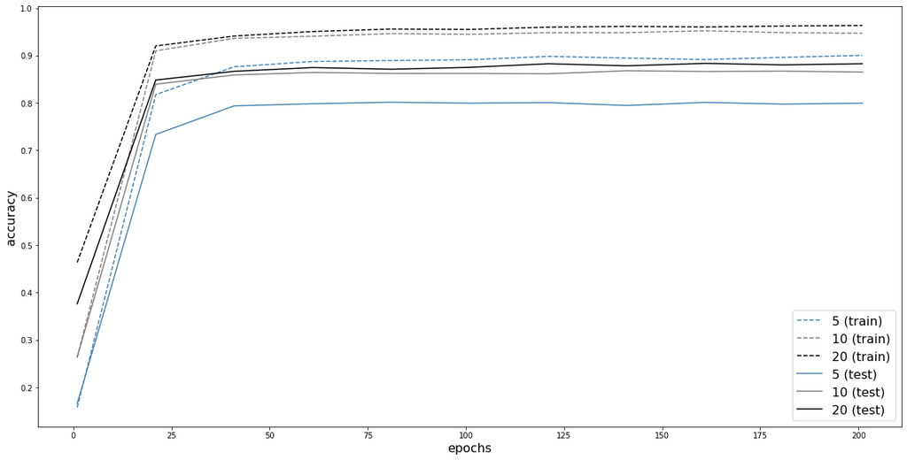

```python
fig, ax = plt.subplots(nrows=1, ncols=1, figsize=(20,10))
epochs_array = [i for i in range(1, 220, 20)]

### BEGIN SOLUTION
ax.plot(epochs_array, nns[0].acc_train_array, color="steelblue", ls='dashed',  label="5 (train)")
ax.plot(epochs_array, nns[1].acc_train_array, color="grey", ls='dashed',  label="10 (train)")
ax.plot(epochs_array, nns[2].acc_train_array, color="black", ls='dashed', label="20 (train)")
### END SOLUTION


### BEGIN SOLUTION
ax.plot(epochs_array, nns[0].acc_test_array, color="steelblue",  label="5 (test)")
ax.plot(epochs_array, nns[1].acc_test_array, color="grey",  label="10 (test)")
ax.plot(epochs_array, nns[2].acc_test_array, color="black",  label="20 (test)")
### END SOLUTION

ax.legend(loc="lower right", fontsize=16)
ax.set_xlabel("epochs", fontsize=16)
ax.set_ylabel("accuracy", fontsize=16)
plt.show()
```

Give your explanation below.

**Solution:** Large hidden layer dimensions produce better results, but take more time to train.

**Extra Credit [10 points]:** Implement dropout by filling the `back_prop_dropout` function and update the `SGD_train` function to use it. Explain the impact of dropout on performance.

```python
from tests import tests
tests.run_test_suite('prob 4', Network)
```

```
TestBackPropDropoutWithoutRegularization (tests.tests.TestNetwork) ...
```

```
Epoch   20: Train    0.50000
```

```
FAIL
TestBackPropDropoutUpdated (tests.tests.TestNetwork) ...
```

```
Epoch   40: Train    0.80000
Epoch   20: Train    0.50000
Epoch   40: Train    0.80000
```

[output not shown]

```python
""" Example Test Runs.

    The effects of dropout may vary from model to model.
    Note your solution did not need to perfom this many runs.
    We are just providing a few studies here to show perfomance impacts.

    Examples:
        EX1: 1x hidden_size=20
        EX2: 3x hidden_size=20
        EX3: 1x hidden_size=60
"""

# EX1: 1 hidden layer w/ hidden_layer_dimensions = 20
hidden_layer_dimensions = 20
print('\nEX1: 1x hidden_size=20, keep_prob=1')
nn = Network([input_dimensions, hidden_layer_dimensions, output_dimensions])
nn.SGD_train(train, epochs=600, eta=0.1, lam=0, verbose=True, test=test)

print('\nEX1: 1x hidden_size=20, keep_prob=0.5')
nn = Network([input_dimensions, hidden_layer_dimensions, output_dimensions], keep_prob=0.5)
nn.SGD_train(train, epochs=600, eta=0.1, lam=0, verbose=True, test=test)

print('\nEX1: 1x hidden_size=20, keep_prob=0.8')
nn = Network([input_dimensions, hidden_layer_dimensions, output_dimensions], keep_prob=0.8)
nn.SGD_train(train, epochs=600, eta=0.1, lam=0, verbose=True, test=test)


# EX2: Deep Network (3 Hidden Layers) w/ hidden_layer_dimensions = 20
hidden_layer_dimensions = 20
print('\nEX2: 3x hidden_size=20, keep_prob=1')
nn = Network([input_dimensions, hidden_layer_dimensions, hidden_layer_dimensions, hidden_layer_dimensions, output_dimensions])
nn.SGD_train(train, epochs=600, eta=0.1, lam=0, verbose=True, test=test)

print('\nEX2: 3x hidden_size=20, keep_prob=0.5')
nn = Network([input_dimensions, hidden_layer_dimensions, hidden_layer_dimensions, hidden_layer_dimensions, output_dimensions], keep_prob = 0.5)
nn.SGD_train(train, epochs=600, eta=0.1, lam=0, verbose=True, test=test)

print('\nEX2: 3x hidden_size=20, keep_prob=0.8')
nn = Network([input_dimensions, hidden_layer_dimensions, hidden_layer_dimensions, hidden_layer_dimensions, output_dimensions], keep_prob = 0.8)
nn.SGD_train(train, epochs=600, eta=0.1, lam=0, verbose=True, test=test)

# EX3: 1 hidden layer w/ hidden_layer_dimensions = 60
hidden_layer_dimensions = 60
print('\nEX3: 1x hidden_size=60, keep_prob=1')
nn = Network([input_dimensions, hidden_layer_dimensions, output_dimensions])
nn.SGD_train(train, epochs=600, eta=0.1, lam=0, verbose=True, test=test)

print('\nEX3: 1x hidden_size=60, keep_prob=0.5')
nn = Network([input_dimensions, hidden_layer_dimensions, output_dimensions], keep_prob=0.5)
nn.SGD_train(train, epochs=600, eta=0.1, lam=0, verbose=True, test=test)

print('\nEX3: 1x hidden_size=60, keep_prob=0.8')
nn = Network([input_dimensions, hidden_layer_dimensions, output_dimensions], keep_prob=0.8)
nn.SGD_train(train, epochs=600, eta=0.1, lam=0, verbose=True, test=test)
```

```
EX1: 1x hidden_size=20, keep_prob=1
Epoch    1: Train    0.36775, Test    0.34134
Epoch   20: Train    0.91797, Test    0.83754
Epoch   40: Train    0.94478, Test    0.84634
Epoch   60: Train    0.95678, Test    0.85674
Epoch   80: Train    0.96399, Test    0.85754
Epoch  100: Train    0.96879, Test    0.85954
Epoch  120: Train    0.97079, Test    0.85714
Epoch  140: Train    0.97279, Test    0.85754
Epoch  160: Train    0.97439, Test    0.85914
Epoch  180: Train    0.97439, Test    0.85954
Epoch  200: Train    0.97519, Test    0.85954
Epoch  220: Train    0.97639, Test    0.85794
Epoch  240: Train    0.97679, Test    0.85714
Epoch  260: Train    0.97719, Test    0.85914
Epoch  280: Train    0.97719, Test    0.85874
Epoch  300: Train    0.97759, Test    0.85674
Epoch  320: Train    0.97759, Test    0.85794
Epoch  340: Train    0.97799, Test    0.85834
Epoch  360: Train    0.97879, Test    0.85634
Epoch  380: Train    0.97959, Test    0.85634
Epoch  400: Train    0.97959, Test    0.85594
Epoch  420: Train    0.97959, Test    0.85554
Epoch  440: Train    0.97999, Test    0.85594
Epoch  460: Train    0.97999, Test    0.85314
Epoch  480: Train    0.98119, Test    0.85554
Epoch  500: Train    0.98159, Test    0.85674
Epoch  520: Train    0.98159, Test    0.85554
Epoch  540: Train    0.98199, Test    0.85714
Epoch  560: Train    0.98199, Test    0.85714
Epoch  580: Train    0.98239, Test    0.85594
Epoch  600: Train    0.98239, Test    0.85674

EX1: 1x hidden_size=20, keep_prob=0.5
Epoch    1: Train    0.23529, Test    0.22249
Epoch   20: Train    0.83553, Test    0.77071
Epoch   40: Train    0.89276, Test    0.82193
Epoch   60: Train    0.91236, Test    0.83673
Epoch   80: Train    0.91757, Test    0.84794
Epoch  100: Train    0.92757, Test    0.85194
```

[output cut: 241 more lines]

```
Epoch  320: Train    0.98279, Test    0.89116
Epoch  340: Train    0.98359, Test    0.89156
Epoch  360: Train    0.98359, Test    0.89196
Epoch  380: Train    0.98359, Test    0.89276
Epoch  400: Train    0.98439, Test    0.89396
Epoch  420: Train    0.98439, Test    0.89436
Epoch  440: Train    0.98439, Test    0.89436
Epoch  460: Train    0.98559, Test    0.89236
Epoch  480: Train    0.98519, Test    0.89716
Epoch  500: Train    0.98559, Test    0.89596
Epoch  520: Train    0.98519, Test    0.89356
Epoch  540: Train    0.98559, Test    0.89476
Epoch  560: Train    0.98599, Test    0.89596
Epoch  580: Train    0.98599, Test    0.89716
Epoch  600: Train    0.98599, Test    0.89676
```

**Solution:** (Check accuracy. Should be around 0.97399/0.88916 for train/test.)

Dropout prevents overfitting. It may lead to slower convergence, but make the model more robust and generalize better.

## [9 points] Problem 4 - Tensors and Autograd.

In this problem, we will demonstrate the benefits of PyTorch's Autograd mechanics by converting your implementation from Problem to utilize PyTorch Tensors. This problem is not meant to be difficult, rather it should be quite simple once you've done Problem 3.

Note that there are *better* ways to go about this which we will cover next. Here. we are keeping things as close to numpy as possible on purpose to show what's going on behind the scenes. Take a moment to look through our modifications to get an understanding of the differences. In the comments, we'll make notes of native torch functions that perform the same operations.

Here, SGD is implemented manually to show you what's going on behind the scenes, but usually you'd use [`torch.optim.SGD`](https://pytorch.org/docs/stable/optim.html#torch.optim.SGD). For future reference, the `weight_decay` parameter implements L2 normilazion.

Before we move forward, let's cover a couple of points on notation.

Just as it's best practice to do `import numpy as np`, PyTorch has best practices for imports as well:

```
import torch
import torch.nn as nn
import torch.nn.functional as F
```

You'll find that many of the functions you've been learning in NumPy have direct translations in PyTorch. The documentation can be found [here](https://pytorch.org/docs/stable/index.html) and is very user friendly, but we'll cover a few notable differences.

- The numpy parameter `axis` becomes `dim` in PyTorch.
- Tensors have [view](https://pytorch.org/docs/stable/tensor_view.html) operations, which avoid copying data unnecasarily. Use these instead of `reshape()`.
- Using `torch.from_numpy()` also avoids copying data stored in `numpy` arrays.
- Numpy interprets `np.dot()` of 2D matrices as matrix multiplication. Pytorch does not have this behaviour, see instead [`torch.matmul()`](https://pytorch.org/docs/stable/generated/torch.matmul.html?highlight=matmul#torch.matmul)
- PyTorch uses trailing underscores such as `torch.add_()` to denote in-place operations. As an example, the following operations are equivilent:

  ```
  x = x + y
  x = torch.add(x, y)
  x.add_(y)
  ```

  You're likely to see these operations when randomly initializing Tensors, or filling a tensor with zeros:

  ```
  torch.nn.init.uniform_(x)
  x.zero_()
  ```

Now onto the problem, your tasks are as follows:

1. Modify `forward_prop` to work on PyTorch Tensors.
2. Modify `SGD_step` to work on PyTorch Tensors. This is easier than it sounds, since with PyTorch we don't have to worry about calculating gradients manually.

```python
import torch


class TorchNetwork(Network):
    def __init__(self, sizes, keep_prob=-1):
        super().__init__(sizes, keep_prob)

        # Convert your weights and biases to Tensors.
        # The flag requires_grad=True tells PyTorch to track gradients for us.
        self.biases = [torch.tensor(b, requires_grad=True) for b in self.biases]
        self.weights = [torch.tensor(w, requires_grad=True) for w in self.weights]


    def g(self, z):
        """ Activation function
            Could also use torch.sigmoid(z)
        """
        return sigmoid_torch(z)

    def forward_prop(self, a):
        """ Memory aware forward propagation.
            Now this is for both training and testing.

        """
        # TODO: Convert your forward_prop function from part a to work on Tensors.
        ### BEGIN SOLUTION
        for (W, b) in zip(self.weights, self.biases):
            a = self.g(torch.matmul(W, a) + b)
        return a
        ### END SOLUTION

    def cost(self, a, y):
        """ Cost function, same as F.mse_loss()
        """
        return ((a - y)**2).mean()


    def SGD_step(self, x, y, eta, lam):
        """
            Performs a single step of SGD on weights and biases

        Args:
            x: single sample features.
            y: single sample target.
            eta: learning rate.
            lam: Regularization parameter.

        """

        # Zero out the old gradients if they exist.
        # Would be optim.zero_grad() if we were using an optimizer.
        for p in (*self.weights, *self.biases):
            if p.grad is not None:
                p.grad.detach_()
                p.grad.zero_()

        # TODO:
        # (1) call forward_prop to get a.
        # (2) Calucate loss using the cost function.
        # (3) Use loss.backward() to to perform backpropagation automatically.

        ### BEGIN SOLUTION
        a = self.forward_prop(x)
        loss = self.cost(a, y)
        loss.backward()
        ### END SOLUTION

        # Perform sgd update
        # Would be optimizer.step()
        with torch.no_grad():
            # l2 regularization on weights only.
            for p in self.weights:
                p.grad.add_(p, alpha=lam)
            # sgd update.
            for p in (*self.weights, *self.biases):
                p.add_(p.grad, alpha=-eta)


def sigmoid_torch(z, threshold=20):
    """ Same as sigmoid before, now with torch.clamp() instead of np.clip().
        We could also just use torch.sigmoid().
    """
    z = torch.clamp(z, -threshold, threshold)
    return 1.0 / (1.0 + torch.exp(-z))
```

**Part 5 [10 points]:** Implement `SGD_step` and `forward_prop`. Use the following test cases to verify if the code is working as expected.

```python
from tests import tests
tests.run_test_suite('prob 5', TorchNetwork)
```

```
TestBackPropWithoutRegularization (tests.tests.TestNetwork) ... ok
TestBackPropWithRegularization (tests.tests.TestNetwork) ... ok

----------------------------------------------------------------------
Ran 2 tests in 0.674s

OK
```

## [23 Points] Problem 5 - Implement RNN Network to classify whether text is spam or ham

Dataset is obtained from UCI Machine Learning repository consisting of SMS tagged messages (labelled as either **ham** (legitimate) or **spam**) that have been collected for SMS Spam research.

We will now use [PyTorch](https://pytorch.org/docs/stable/index.html) (Pytorch Lightning to be precise) to implement a classifier. Update the snippet below to build a model with an embedding layer, and an LSTM layer, and a dense layer. This question allows you to get familiar with popular deep learning toolkits and the solution only has a few lines. In practice, there is no need to reinvent the wheels.

Learn more about RNN : https://colah.github.io/posts/2015-08-Understanding-LSTMs/

**Note**: You need to install Tensorflow for this problem (CPU version if you do not have a nvidia GPU). You can find installation instructions [here](https://www.tensorflow.org/install)

The following class converts textual data to sequences of numbers. Initially, we create a vocabulary of words such that each word is associated with a particular number. Then, for each new sentence, each word is replaced by its corresponding encoding.

For example, if we had an encoding : "I" : 1, "am" : 5, "alive" : 9 Then the sentence "I am alive" would be represented as [1, 5, 9]

Now, since sentences can be of varying lengths and inputs to neural networks are fixed in size, we the input size to our model to be lager than the largest sentence and pad smaller sentences with 0's.

```python
import multiprocessing as mp
import pickle
import pandas as pd
import pytorch_lightning as pl
import torch
import torch.nn as nn
import torch.nn.functional as F

from tensorflow.keras.preprocessing import sequence
from tensorflow.keras.preprocessing.text import Tokenizer
from torch.utils.data import DataLoader, TensorDataset

import pytorch_lightning as pl
from pytorch_lightning.loggers import CSVLogger

class SpamHam(pl.LightningDataModule):
    """ A datamodule for the RNN. You shouldn't have to modify this class."""
    def __init__(self, dict_size=5000, example_length=150, batch_size=128):
        super().__init__()

        self.dict_size = dict_size
        self.batch_size = batch_size
        self.example_length = example_length

        # preprocess training data
        self.tok = Tokenizer(num_words=dict_size)

    def load_data(self, location):
        return pickle.load(open(location, 'rb'))

    def make_dataset(self, x, y, tok=None):
        # tokenize
        sequences = self.tok.texts_to_sequences(x)
        x = sequence.pad_sequences(sequences, maxlen=self.example_length)

        # make torch arrays.
        x = torch.from_numpy(x).to(torch.int64)
        y = torch.from_numpy(y).to(torch.float32)

        return TensorDataset(x, y)

    def setup(self, stage):
        # load data
        train_x, test_x, train_y, test_y = self.load_data('./data/spam_data.pkl')

        # fit tokenizer
        self.tok.fit_on_texts(train_x)

        # make datasets
        self.train = self.make_dataset(train_x, train_y)
        self.test = self.make_dataset(test_x, test_y)

    def train_dataloader(self):
        return DataLoader(self.train, batch_size=self.batch_size, shuffle=True,
                          num_workers=mp.cpu_count() // 4)

    def test_dataloader(self):
        return DataLoader(self.test, batch_size=self.batch_size, shuffle=False,
                          num_workers=mp.cpu_count() // 4)
```

### Part 1 [15 points]

PyTorch Lightning expects your model to follow a standard class template. Once certain functions are completed, pl.Trainer() allows you train the model without explicitly writing a training loop. In the following example, you need to define the model and how the input is propagated through the model (called the forward pass) and then create the training and test steps.

Complete the functions `init`, `training_step`, and `test_step` and `forward`functions.

```python
class RNN(pl.LightningModule):
    """ RNN classifier """

    def __init__(self, embedding_length=32, dict_size=5000, example_length=150):
        """
        initialize RNN model
        :param embedding_length: size of word embedding
        """
        super().__init__()

        # To complete this function, you will need PyTorch's Embedding, LSTM and linear layers.

        # The embedding layer simply creates a dictionary between words in your vocabulary and their vector
        # representations. Therefore, each word has a unique representation.
        # For instance, say your input x is encoded as [1, 5, 9] and embedding_dim = 32 (see documentation for
        # arguments to this layer), then after passing through the embedding layer the output will be
        # of shape 3x32

        # Documentation for LSTM layer in :
        #     https://pytorch.org/docs/stable/generated/torch.nn.LSTM.html#torch.nn.LSTM

        # Note there are multiple ways to define your model,
        # we suggest adding individual layers here, but any method is fine.

        # As an example, you could define a linear layer with n inputs and m outputs like so:
        # self.linear = nn.Linear(n, m)

        # Similarly, define the three layers needed for your model

        # TODO: build model by defining individual layers in the network

        ### BEGIN SOLUTION
        self.embedding = nn.Embedding(num_embeddings=dict_size,
                                      embedding_dim=embedding_length)
        self.lstm = nn.LSTM(embedding_length, embedding_length, batch_first=True)
        self.out = nn.Linear(embedding_length, 1)
        ### END SOLUTION

        self.example_input_array = torch.zeros([1, 150], dtype=torch.int64)

    def configure_optimizers(self):
        return torch.optim.Adam(self.parameters())

    def forward(self, x):
        """

        Pytorch allows you to stack layers on top of each other very easily.

        For example, if we have layers self.layer1 and self.layer2 acting on input x, we can do
        out_1 = self.layer1(x)
        out_2 = self.layer2(out_1)
        This would constitute a forward pass for the above hypothetical network.

        Your job in this function is to propagate the input x through the network you defined in __init__()

        TODO:
        1. Pass input though embedding layer
        2. Propagate output of previous step through LSTM
        3. Pass final output of LSTM through linear layer
        4. Apply Sigmoid activation (torch.sigmoid()) to output of step 3 to obtain probabilities
        """

        ### BEGIN SOLUTION
        x = self.embedding(x)
        x, h = self.lstm(x)
        x = x[:, -1, :]
        out = torch.sigmoid(self.out(x))
        ### END SOLUTION
        return out

    def accuracy(self, y_hat, y):
        return (y == y_hat.round()).to(torch.float32).mean()

    def training_step(self, batch, batch_idx):
        """ Perfom a training step.

        This is just one step on one batch during training (no looping required)

        TODO:
            - forward pass on data in batch
            - compute training loss (use PyTorch's F.binary_cross_entropy since this is binary classification)
            - Compute training accuracy (using the self.accuracy function)
        """

        ### BEGIN SOLUTION
        x, y = batch
        y_hat = self(x)
        loss = F.binary_cross_entropy(y_hat, y)
        acc = self.accuracy(y_hat, y)
        ### END SOLUTION

        # We implemented logging for you.
        result = pl.TrainResult(loss)
        result.log('train_loss', loss)
        result.log('train_accuracy', acc, prog_bar=True)
        return result

    def test_step(self, batch, batch_idx):
        """ Perfom a test step
            hint: your code should be the same as your train step

        TODO:
            - forward pass on data in batch
            - compute test loss
            - Compute test accuracy
        """

        ### BEGIN SOLUTION
        x, y = batch
        y_hat = self(x)
        loss = F.binary_cross_entropy(y_hat, y)
        acc = self.accuracy(y_hat, y)
        ### END SOLUTION

        # We implemented logging for you.
        result = pl.EvalResult(loss)
        result.log('test_loss', loss, prog_bar=True)
        result.log('test_acc', acc, prog_bar=True)

        return result
```

```python
# Define your data
spam_ham_dm = SpamHam()

def run_rnn(**kwargs):
    # helper function for running RNN.
    logger = CSVLogger("logs", name="rnn")
    trainer = pl.Trainer(
        gpus=int(torch.cuda.is_available()),
        logger=logger,
        min_epochs=5,
        max_epochs=5,
        row_log_interval=1,
        log_save_interval=1,
        deterministic=True
    )

    model = RNN(**kwargs)
    trainer.fit(model, spam_ham_dm)
    results = trainer.test(verbose=False)
    return results, logger.experiment.metrics_file_path

results, _ = run_rnn()
print('Accuracy for LSTM: ', results[0]['test_acc'])
```

```
GPU available: True, used: True
TPU available: False, using: 0 TPU cores
CUDA_VISIBLE_DEVICES: [0]

  | Name      | Type      | Params | In sizes     | Out sizes
--------------------------------------------------------------------------------------------------
0 | embedding | Embedding | 160 K  | [1, 150]     | [1, 150, 32]
1 | lstm      | LSTM      | 8 K    | [1, 150, 32] | [[1, 150, 32], [[1, 1, 32], [1, 1, 32]]]
2 | out       | Linear    | 33     | [1, 32]      | [1, 1]
```

```
Saving latest checkpoint..
```

```
Accuracy for LSTM:  0.9633010029792786
```

**Solution:** (Check accuracy. Should be around 0.9664273858070374.)

### Part 2 [8 points]

- Change the embedding length and experiment with these values: [8, 16, 32, 48, 64].
- Plot training accuracies of different embedding lengths vs. epochs.
- Observe and explain the impact of embedding length in LSTM Model.

```python
mfiles = []
test_accuracy_array = []

for embedding_len in [8, 16, 32, 48, 64]:
    results, metrics = run_rnn(embedding_length=embedding_len)
    print('Accuracy for LSTM: ', results[0]['test_acc'])
    mfiles.append(metrics)

train_accuracy_matrix = np.array(
    [pd.read_csv(f)["train_accuracy"].values for f in mfiles])
```

```
GPU available: True, used: True
TPU available: False, using: 0 TPU cores
CUDA_VISIBLE_DEVICES: [0]

  | Name      | Type      | Params | In sizes    | Out sizes
----------------------------------------------------------------------------------------------
0 | embedding | Embedding | 40 K   | [1, 150]    | [1, 150, 8]
1 | lstm      | LSTM      | 576    | [1, 150, 8] | [[1, 150, 8], [[1, 1, 8], [1, 1, 8]]]
2 | out       | Linear    | 9      | [1, 8]      | [1, 1]
```

```
Saving latest checkpoint..
```

```
GPU available: True, used: True
TPU available: False, using: 0 TPU cores
CUDA_VISIBLE_DEVICES: [0]

  | Name      | Type      | Params | In sizes     | Out sizes
--------------------------------------------------------------------------------------------------
0 | embedding | Embedding | 80 K   | [1, 150]     | [1, 150, 16]
1 | lstm      | LSTM      | 2 K    | [1, 150, 16] | [[1, 150, 16], [[1, 1, 16], [1, 1, 16]]]
2 | out       | Linear    | 17     | [1, 16]      | [1, 1]
```

```
Accuracy for LSTM:  0.8725709319114685
```

```
Saving latest checkpoint..
```

```
GPU available: True, used: True
TPU available: False, using: 0 TPU cores
CUDA_VISIBLE_DEVICES: [0]

  | Name      | Type      | Params | In sizes     | Out sizes
--------------------------------------------------------------------------------------------------
0 | embedding | Embedding | 160 K  | [1, 150]     | [1, 150, 32]
1 | lstm      | LSTM      | 8 K    | [1, 150, 32] | [[1, 150, 32], [[1, 1, 32], [1, 1, 32]]]
2 | out       | Linear    | 33     | [1, 32]      | [1, 1]
```

```
Accuracy for LSTM:  0.940979540348053
```

```
Saving latest checkpoint..
```

```
GPU available: True, used: True
TPU available: False, using: 0 TPU cores
CUDA_VISIBLE_DEVICES: [0]

  | Name      | Type      | Params | In sizes     | Out sizes
--------------------------------------------------------------------------------------------------
0 | embedding | Embedding | 240 K  | [1, 150]     | [1, 150, 48]
1 | lstm      | LSTM      | 18 K   | [1, 150, 48] | [[1, 150, 48], [[1, 1, 48], [1, 1, 48]]]
2 | out       | Linear    | 49     | [1, 48]      | [1, 1]
```

```
Accuracy for LSTM:  0.9533876180648804
```

```
Saving latest checkpoint..
```

```
GPU available: True, used: True
TPU available: False, using: 0 TPU cores
CUDA_VISIBLE_DEVICES: [0]

  | Name      | Type      | Params | In sizes     | Out sizes
--------------------------------------------------------------------------------------------------
0 | embedding | Embedding | 320 K  | [1, 150]     | [1, 150, 64]
1 | lstm      | LSTM      | 33 K   | [1, 150, 64] | [[1, 150, 64], [[1, 1, 64], [1, 1, 64]]]
2 | out       | Linear    | 65     | [1, 64]      | [1, 1]
```

```
Accuracy for LSTM:  0.9811581373214722
```

```
Saving latest checkpoint..
```

```
Accuracy for LSTM:  0.9822741746902466
```

Plot training results below.

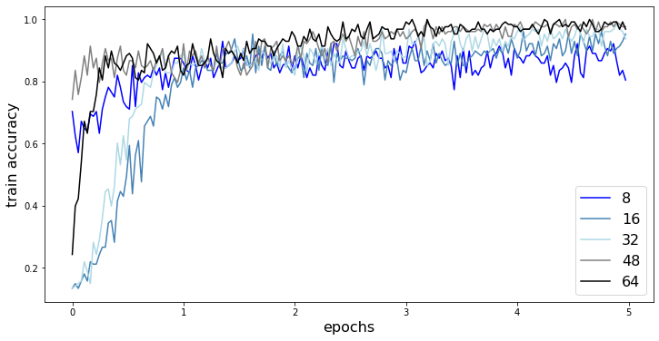

```python
fig, ax = plt.subplots(nrows=1, ncols=1, figsize=(12,6))
labels = list(map(str, [8, 16, 32, 48, 64]))

xplot = np.linspace(0, 5, train_accuracy_matrix.shape[1])

epochs_array = [i for i in range(1,6)]
ax.plot(xplot, train_accuracy_matrix[0], color="blue", label=labels[0])
ax.plot(xplot, train_accuracy_matrix[1], color="steelblue", label=labels[1])
ax.plot(xplot, train_accuracy_matrix[2], color="lightblue", label=labels[2])
ax.plot(xplot, train_accuracy_matrix[3], color="grey", label=labels[3])
ax.plot(xplot, train_accuracy_matrix[4], color="black", label=labels[4])
ax.legend(loc="lower right", fontsize=16)
ax.set_xlabel("epochs", fontsize=16)
ax.set_ylabel("train accuracy", fontsize=16)
plt.show()
```

Give your observation and explanation below.

### Optional survey.

We are always interested in your feedback. At the end of each homework, there is a simple anonymous feedback [survey](https://forms.gle/6Kf72C26am1SAjtg6) to solicit your feedback for how to improve the course.